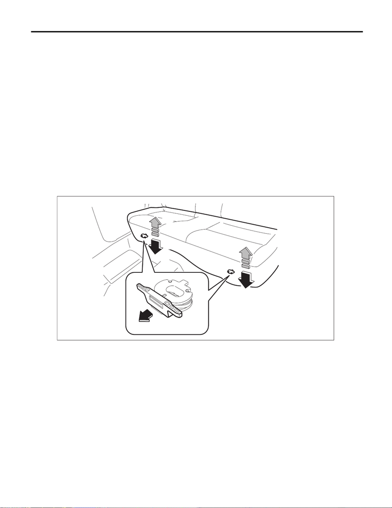

SE-29

Rear Seat

SEATS

3. Rear Seat

A: REMOVAL

1) Disconnect the ground cable from battery and wait for at least 60 seconds before starting work. <Ref. to

NT-5, BATTERY, NOTE, Note.>

NOTE:

For models other than STI model, disconnect the ground terminal from battery sensor.

CAUTION:

• Airbag system satellite safing sensor is located in the lower of the rear seat cushion center. Before

removing the rear seat, refer to “CAUTION” of “General Description” in “AIRBAG SYSTEM” section.

<Ref. to AB-9, CAUTION, General Description.>

• The airbag system is fitted with a backup power supply. After disconnecting the battery ground ca-

ble, the airbag may operate if you do not wait for 60 seconds before starting the service of airbag sys-

tem.

2) Remove the rear seat cushion assembly.

(1) Push the corners of the rear seat cushion from above.

(2) While pushing the corners of the rear seat cushion from above, pull the knob of the hook - seat cush-

ion rear towards yourself.

(3) While pulling the knob towards yourself, disconnect the hooks by lifting up the rear seat cushion.

SE-01494

(3)

(1)

(3)

(1)

(2)

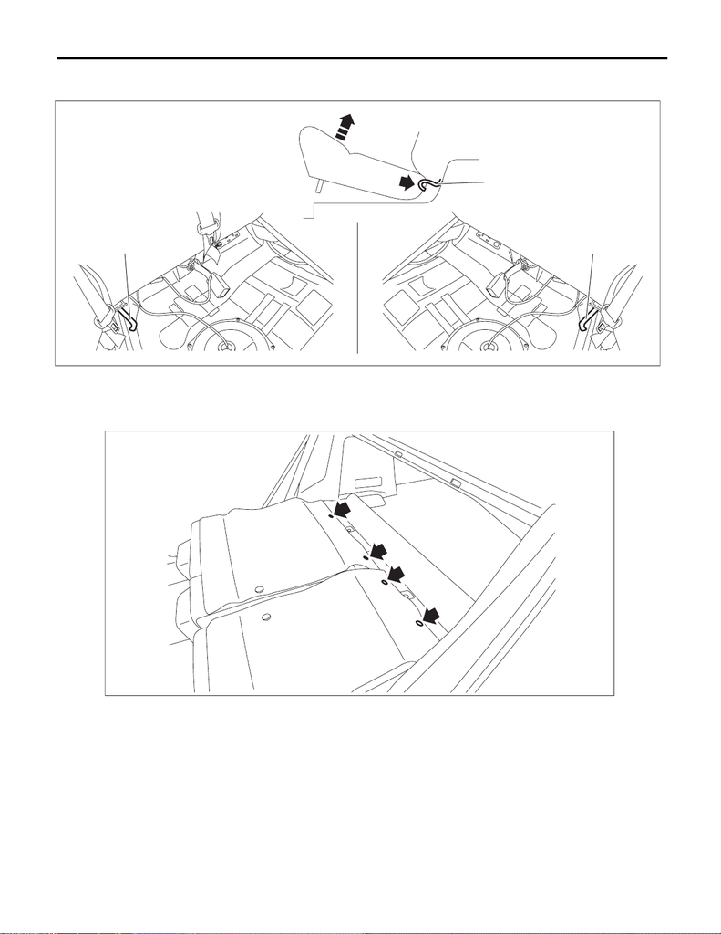

SE-30

Rear Seat

SEATS

(4) Remove the hook (A) by pushing it back while lifting the front side of the rear seat cushion, and re-

move the rear seat cushion.

3) Remove the backrest assembly LH.

(1) Tilt the backrest assembly LH forward.

(2) Remove the clips located at the bottom of the cover COMPL - rear backrest LH and RH of the rear

seat back.

(A)

SE-01307

(A)

(A)

SE-01309

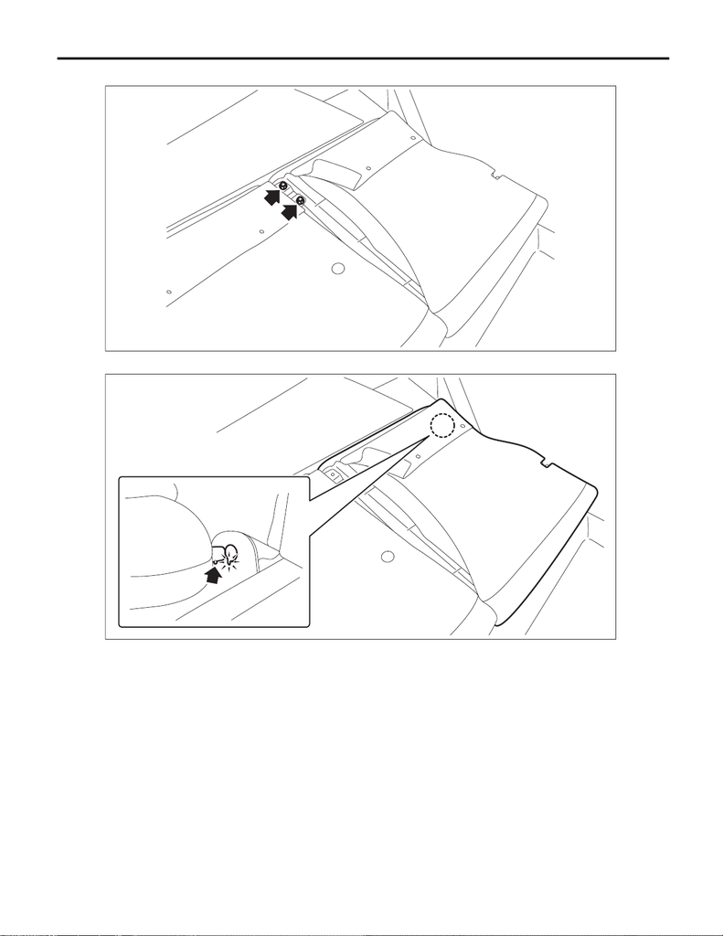

SE-31

Rear Seat

SEATS

(3) Turn over the cover COMPL - rear backrest LH to remove the bolts.

(4) Remove the backrest assembly LH from the hinge assembly.

NOTE:

The backrest assembly cannot be removed unless pin positions on the hinge assembly side and backrest as-

sembly side are aligned.

SE-01310

SE-01311

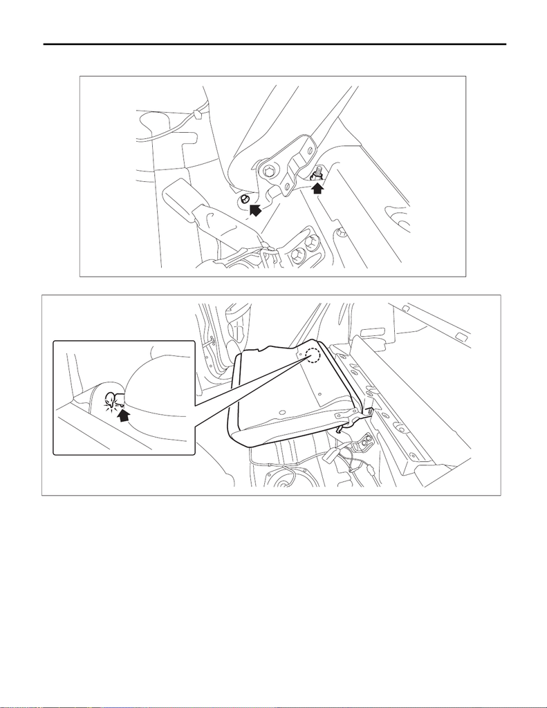

SE-32

Rear Seat

SEATS

4) Remove the backrest assembly RH.

(1) Remove the bolts and nuts.

(2) Remove the backrest assembly RH from the hinge assembly.

NOTE:

The backrest assembly cannot be removed unless pin positions on the hinge assembly side and backrest as-

sembly side are aligned.

SE-01312

SE-01313

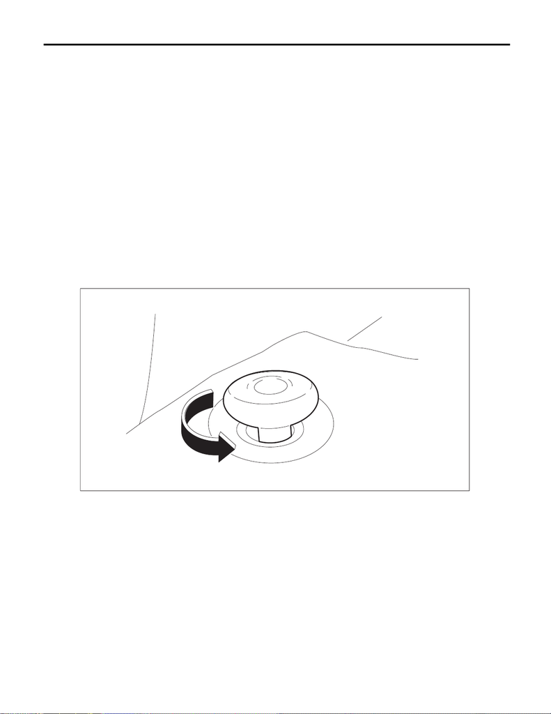

SE-33

Rear Seat

SEATS

B: INSTALLATION

1) Install the backrest assembly RH and LH.

Tightening torque:

33 N·m (3.4 kgf-m, 24.3 ft-lb)

NOTE:

• After installing the backrest assembly, make sure that each seat belt operates normally.

• Make sure that they are properly secured on each hook on the vehicle side.

2) Install the rear seat cushion assembly.

3) Connect the battery ground terminal. <Ref. to NT-5, BATTERY, NOTE, Note.>

NOTE:

For models other than STI model, connect the ground terminal to battery sensor.

Tightening torque:

Refer to “COMPONENT” of “General Description”. <Ref. to SE-7, REAR SEAT, COMPONENT, Gen-

eral Description.>

C: DISASSEMBLY

1) Remove the rear seat. <Ref. to SE-29, REMOVAL, Rear Seat.>

2) Remove the headrest assembly - rear backrest.

3) Remove the knob - backrest. (Screw-in type)

SE-01314

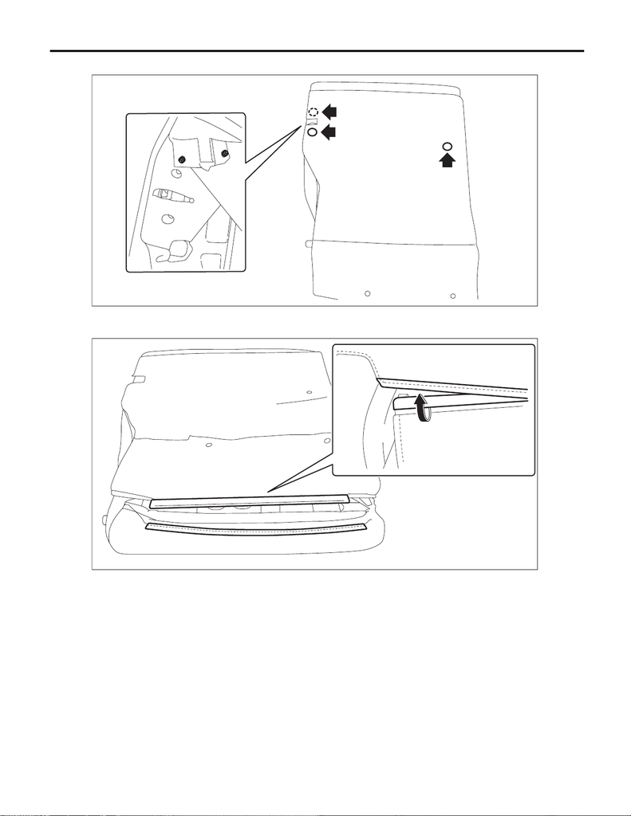

SE-34

Rear Seat

SEATS

4) Remove the clips on the backside of the cover COMPL - rear backrest LH.

5) Detach the plastic fastener at the bottom of backrest assembly LH and turn over the cover COMPL - rear

backrest LH.

SE-01315

SE-01316

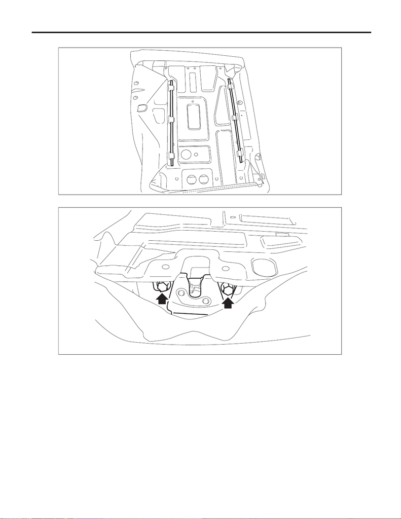

SE-35

Rear Seat

SEATS

6) Remove the plastic hooks on the back side of the backrest assembly LH.

7) Remove the lock assembly - rear backrest rear LH.

SE-01317

SE-01318

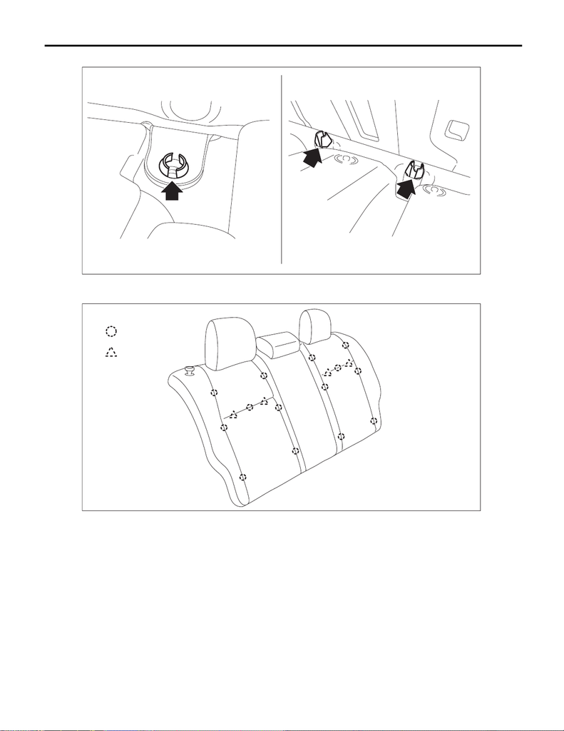

SE-36

Rear Seat

SEATS

8) Remove the bushing - headrest and the bushing - lock assembly.

9) Remove the pad assembly - main LH from the frame assembly - rear backrest LH.

10) Remove the hog rings (A) and wire clip (B), then remove the cover COMPL - rear backrest LH.

SE-01319

SE-01700

: A

: B

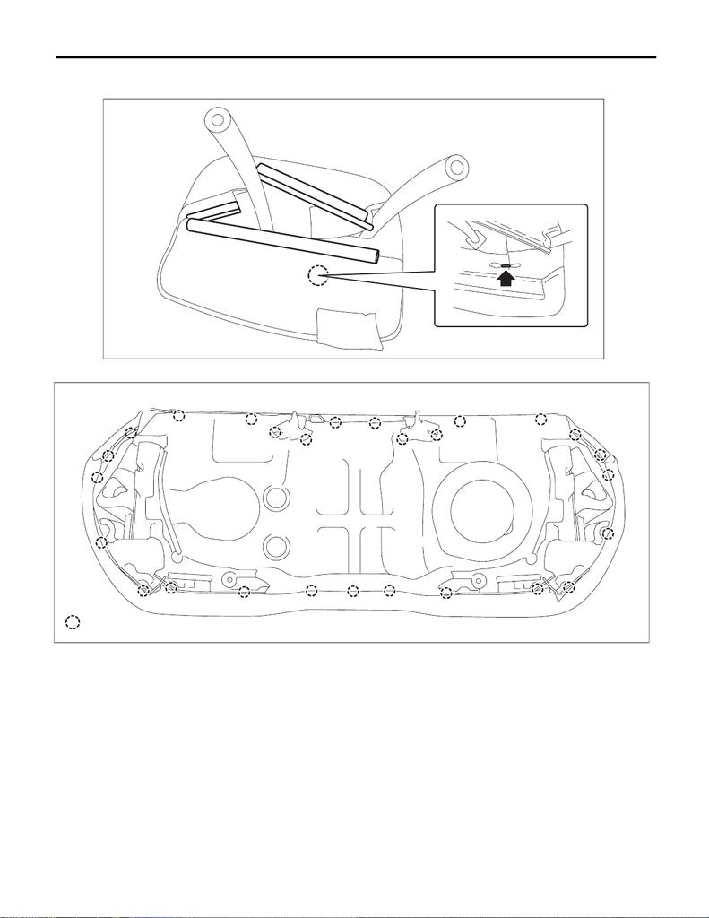

SE-37

Rear Seat

SEATS

11) Referring to the above steps, disassemble the backrest assembly RH.

12) Detach the plastic fastener and hog ring, and then remove the headrest cover.

13) Remove the hog rings (A) on the back side of the rear seat cushion assembly.

SE-01321

SE-01322

: (A)

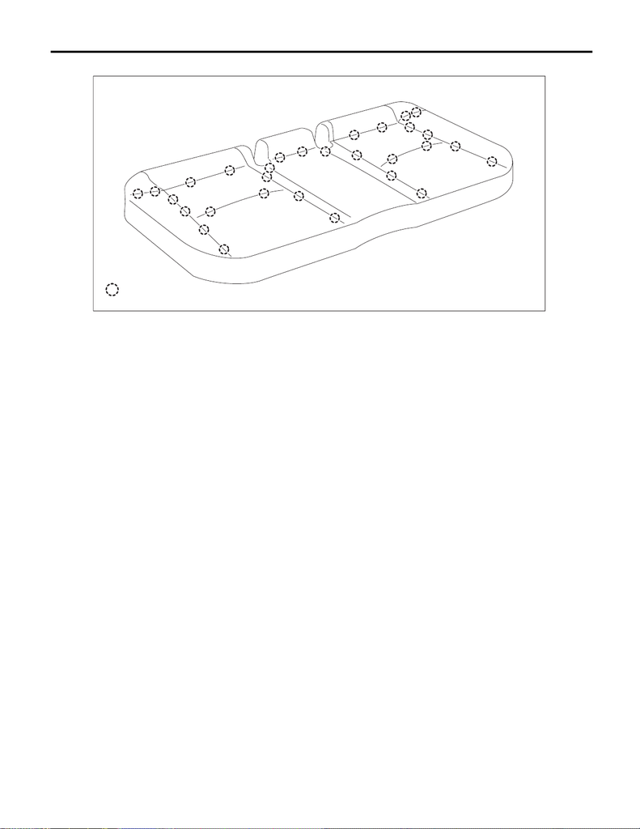

SE-38

Rear Seat

SEATS

14) Remove the hog rings (A), then remove the cover - rear cushion.

D: ASSEMBLY

CAUTION:

• Do not reuse hog rings.

• Secure the hog ring using hog ring pliers.

• Install the hog rings to the specified points securely and make sure that there is no wrinkle or twist-

ing on the cover COMPL - rear backrest.

1) Assemble the cover COMPL - rear backrest and the cover - rear cushion in the same manner as for the

front seat. <Ref. to SE-23, ASSEMBLY, Front Seat.>

2) Install the hog rings (A) on the back side of the rear seat cushion assembly.

3) Install the hog rings and wire clip, then install the cover COMPL - rear backrest LH.

NOTE:

• Do not contaminate or damage the cover COMPL - rear backrest and the cover - rear cushion.

• While installing the hog rings, prevent the cover COMPL - rear backrest and the cover - rear cushion from

getting wrinkled.

4) Install the plastic fastener and hog ring, and then install the headrest cover.

5) Install the pad assembly - main LH.

6) Install the bushing - headrest and the bushing - lock assembly.

7) Install the lock assembly - rear backrest rear LH.

Tightening torque:

22.5 N·m (2.3 kgf-m, 16.6 ft-lb)

8) Install the plastic hooks on the back side of the backrest assembly LH.

9) Install the clips on the backside of the cover COMPL - rear backrest LH.

10) Install the knob - backrest. (Screw-in type)

11) Referring to the above steps, install the pad assembly - main RH.

Tightening torque:

Refer to “COMPONENT” of “General Description”. <Ref. to SE-7, REAR SEAT, COMPONENT, Gen-

eral Description.>

12) Install the headrest assembly - rear backrest.

13) Before installation, check the following items.

• No tear and fray on the cover COMPL - rear backrest and the cover - rear cushion.

• No fray or deformation on each wire cable.

14) Install the rear seat. <Ref. to SE-33, INSTALLATION, Rear Seat.>

SE-01713

: (A)